# CsgG

Fold-switch pair **4q79F_4uv2D** — **4q79F** vs **4uv2D**

Escherichia coli Xuzhou21 / Escherichia coli str. K-12 substr. MC4100

## Figure 1: Phylogenetic tree with per-cluster fold-preference heatmap.

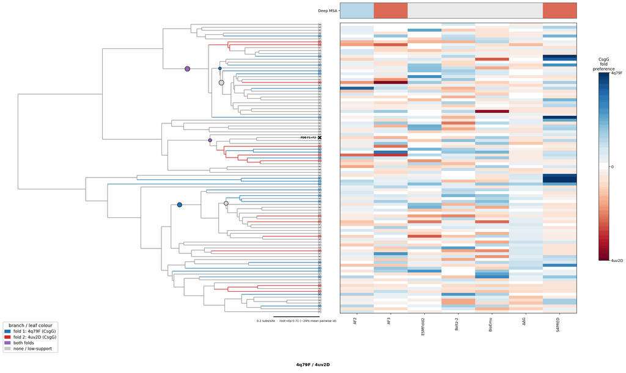

## Figure 2: Aligned overlay (both folds superposed)

The single fold-switching chain of each fold superposed by TM-align; waters hidden, any ligand shown as green sticks. Grey = structurally conserved core, colour = divergent (fold-switching) region.

4q79F (CsgG)4uv2D (CsgG)Ligand HG (bound to 4q79F), Ligand MSE (bound to 4uv2D)

TM-score: 0.764 · Trigger class: ligand

Aligned overlay

Loading...

## Figure 3: The two folds, side by side

Each fold is coloured by per-residue Cα deviation between the two superposed structures: grey ≈ conserved core, full colour = structurally divergent (fold-switching) region.

4q79F (CsgG)

4uv2D (CsgG)

0 Å5≥10 Å

4q79F (CsgG)

Loading...

4uv2D (CsgG)

Loading...

## Figure 4: Best-cluster predicted contact maps over the two true folds.

Predicted contact maps (MSA-Transformer) for the clusters best matching each fold, over the true contacts of fold 1 (upper triangle) and fold 2 (lower). Divergent contacts between clusters are the contact-level signature of fold-switching.

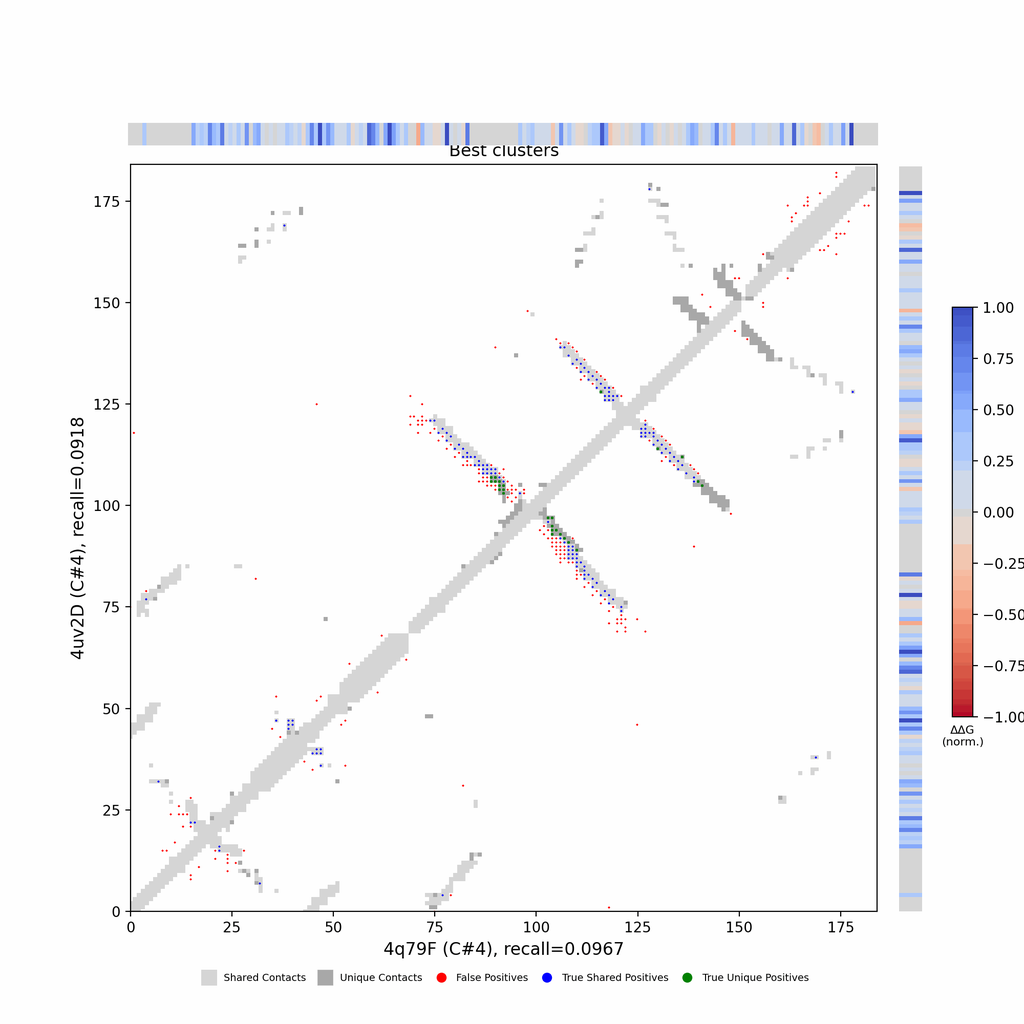

## Figure 5: Per-residue ΔΔG fold-preference contribution

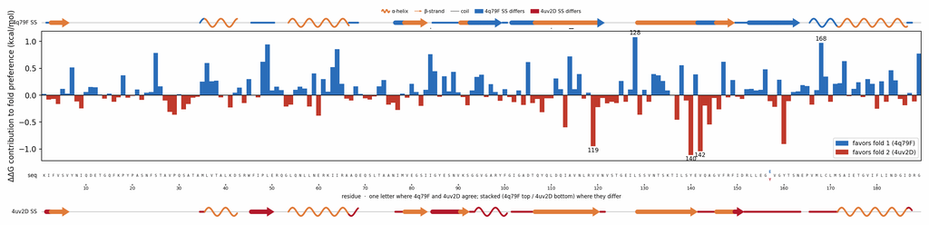

**More figures**

## Figure 6: Deep-MSA contact map panel / Best clusters contact map panel

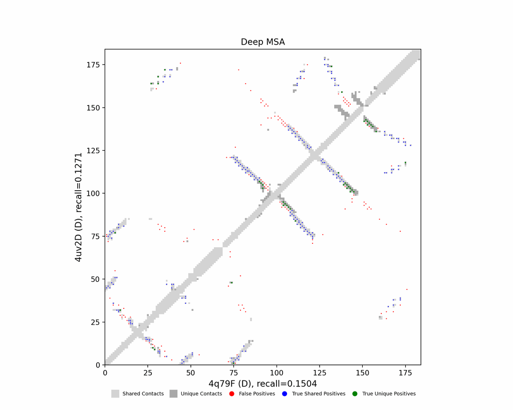

Deep-MSA contact map panel

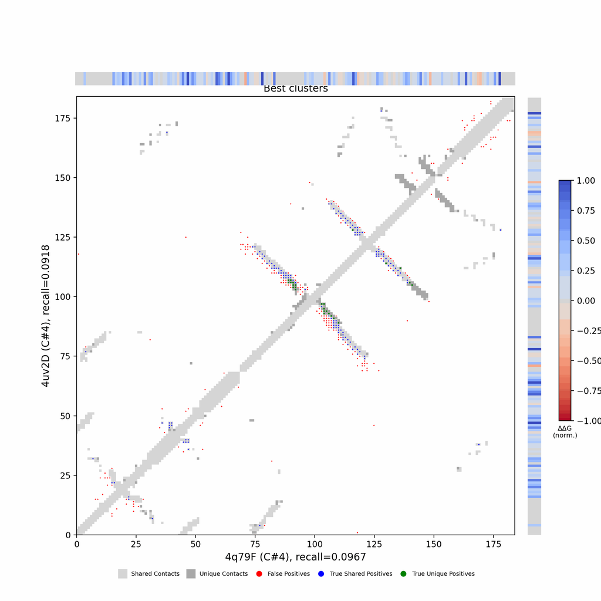

Best clusters contact map panel

## Figure 7: All clusters contact-map mosaic (small multiples).

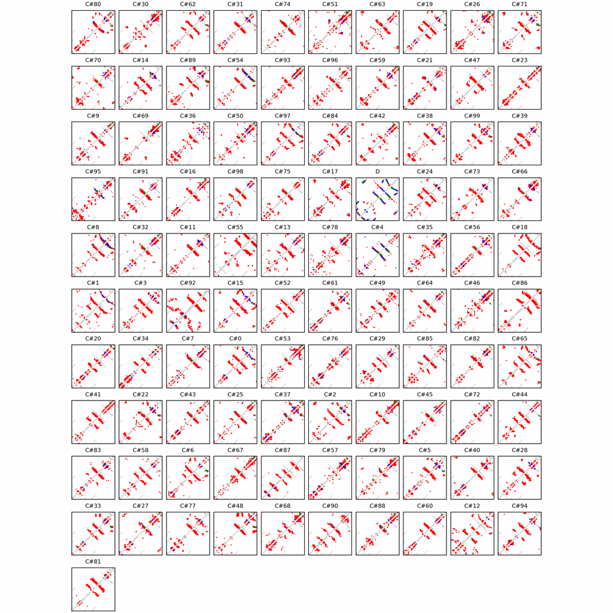

## Figure 8: Phylo null: tree with shuffled cluster fold labels.

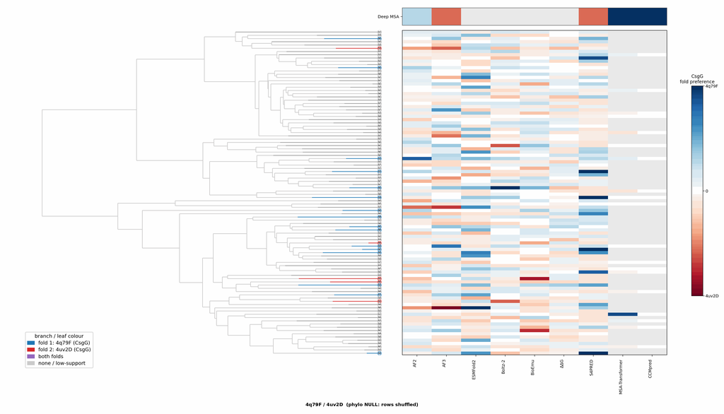

## Cluster metrics table

Per-cluster metrics underlying the figures above.

| cluster | n | neff | AF2_TM1 | AF2_TM2 | AF3_TM1 | AF3_TM2 | RE-MSAT-COM | RE-MSAT1 | RE-MSAT2 | ESM_SEQIDS | ESM_TM1 | ESM_TM2 | ΔΔG_Bias | ΔΔG_Bias_std | ΔΔG_frac_F1 | Boltz2_pref | S4PRED_pref | CCMpred_pref | BioEmu_pref |
| --- | --- | --- | --- | --- | --- | --- | --- | --- | --- | --- | --- | --- | --- | --- | --- | --- | --- | --- | --- |
| Deep | - | - | 0.9 | 0.84 | 0.8 | 0.94 | 0.2 | 0.48 | 0.15 | - | - | - | - | - | - | - | -0.11 | 0.0 | - |
| 000 | 183.0 | 60.0 | 0.28 | 0.24 | 0.73 | 0.5 | 0.02 | 0.01 | 0.04 | 004; 004; 001; 007; 007; 001; 006; 006; 005; 005 | 0.78 ± 0.01 | 0.78 ± 0.08 | 20.63 | 12.23 | 1.0 | 0.08 | -0.04 | 0.0 | 0.06 |
| 001 | 161.0 | 61.0 | 0.62 | 0.56 | 0.61 | 0.47 | 0.0 | 0.02 | 0.07 | 005; 005; 002; 002; 001; 004; 001; 004; 003; 003 | 0.76 ± 0.03 | 0.70 ± 0.07 | 26.44 | 11.37 | 1.0 | -0.01 | -0.11 | 0.0 | 0.04 |
| 002 | 123.0 | 42.0 | 0.38 | 0.39 | 0.44 | 0.4 | 0.0 | 0.01 | 0.03 | 005; 005; 003; 003; 001; 004; 001; 004; 002; 002 | 0.70 ± 0.11 | 0.65 ± 0.15 | 25.26 | 12.19 | 1.0 | 0.01 | -0.09 | 0.0 | 0.02 |
| 003 | 122.0 | 31.0 | 0.31 | 0.27 | 0.39 | 0.33 | 0.0 | 0.0 | 0.01 | 006; 005; 005; 006; 001; 004; 001; 004; 002; 002 | 0.70 ± 0.13 | 0.63 ± 0.15 | 25.93 | 13.1 | 1.0 | 0.03 | -0.1 | 0.0 | 0.03 |
| 004 | 121.0 | 40.0 | 0.29 | 0.29 | 0.34 | 0.35 | 0.01 | 0.21 | 0.02 | 007; 007; 008; 008; 009; 009; 001; 006; 001; 006 | 0.79 ± 0.03 | 0.76 ± 0.06 | 18.01 | 13.75 | 1.0 | 0.03 | -0.1 | 0.0 | 0.05 |
| 005 | 119.0 | 47.0 | 0.32 | 0.27 | 0.4 | 0.36 | 0.0 | 0.0 | 0.02 | 006; 009; 008; 007; 006; 007; 008; 009; 001; 001 | 0.78 ± 0.01 | 0.73 ± 0.06 | 22.02 | 10.85 | 1.0 | 0.02 | -0.08 | 0.0 | 0.03 |
| 006 | 113.0 | 22.0 | 0.26 | 0.27 | 0.47 | 0.39 | 0.0 | 0.01 | 0.0 | 004; 004; 006; 007; 007; 006; 005; 005; 008; 008 | 0.77 ± 0.01 | 0.78 ± 0.04 | 23.21 | 9.24 | 1.0 | 0.04 | 0.08 | 0.0 | -0.02 |
| 007 | 107.0 | 22.0 | 0.32 | 0.25 | 0.42 | 0.37 | 0.0 | 0.0 | 0.01 | 004; 004; 008; 008; 007; 007; 001; 006; 001; 006 | 0.78 ± 0.02 | 0.70 ± 0.06 | 21.9 | 11.95 | 1.0 | 0.08 | -0.1 | 0.0 | 0.03 |
| 008 | 106.0 | 38.0 | 0.35 | 0.3 | 0.39 | 0.36 | 0.0 | 0.03 | 0.06 | 008; 008; 005; 005; 002; 002; 001; 001; 006; 006 | 0.71 ± 0.06 | 0.60 ± 0.06 | 21.51 | 10.4 | 1.0 | 0.05 | -0.09 | 0.0 | 0.01 |
| 009 | 96.0 | 21.0 | 0.24 | 0.26 | 0.34 | 0.27 | 0.0 | 0.01 | 0.05 | 005; 005; 006; 006; 001; 001; 007; 007; 008; 008 | 0.63 ± 0.07 | 0.53 ± 0.03 | 21.63 | 11.31 | 1.0 | 0.02 | -0.11 | 0.0 | 0.02 |
| 010 | 95.0 | 6.0 | 0.27 | 0.21 | 0.52 | 0.46 | 0.0 | 0.01 | 0.01 | 005; 005; 001; 004; 001; 004; 006; 006; 007; 007 | 0.73 ± 0.05 | 0.66 ± 0.06 | 25.34 | 10.61 | 1.0 | 0.04 | -0.02 | 0.0 | 0.02 |
| 011 | 91.0 | 28.0 | 0.42 | 0.36 | 0.49 | 0.44 | 0.0 | 0.0 | 0.04 | 001; 004; 004; 006; 006; 001; 007; 007; 005; 005 | 0.75 ± 0.05 | 0.68 ± 0.06 | 21.71 | 9.84 | 1.0 | 0.05 | -0.11 | 0.0 | 0.03 |
| 012 | 85.0 | 66.0 | 0.79 | 0.58 | 0.84 | 0.72 | 0.0 | 0.01 | 0.01 | 007; 008; 008; 007; 004; 009; 004; 005; 006; 009 | 0.78 ± 0.00 | 0.78 ± 0.02 | 21.97 | 6.68 | 1.0 | 0.01 | -0.03 | 0.0 | 0.04 |
| 013 | 82.0 | 14.0 | 0.26 | 0.26 | 0.64 | 0.53 | 0.0 | 0.0 | 0.02 | 005; 005; 004; 004; 002; 002; 008; 008; 001; 007 | 0.55 ± 0.14 | 0.50 ± 0.14 | 16.68 | 6.12 | 1.0 | 0.02 | -0.1 | 0.0 | 0.0 |
| 014 | 82.0 | 14.0 | 0.25 | 0.22 | 0.54 | 0.46 | 0.0 | 0.01 | 0.05 | 001; 001; 009; 009; 008; 008; 005; 005; 002; 002 | 0.75 ± 0.05 | 0.66 ± 0.08 | 19.96 | 5.71 | 1.0 | 0.06 | -0.1 | 0.0 | -0.0 |
| 015 | 78.0 | 30.0 | 0.32 | 0.29 | 0.48 | 0.44 | 0.02 | 0.02 | 0.03 | 001; 005; 005; 001; 006; 003; 003; 006; 008; 008 | 0.79 ± 0.01 | 0.73 ± 0.07 | 21.99 | 7.22 | 1.0 | 0.02 | -0.03 | 0.0 | 0.02 |
| 016 | 77.0 | 11.0 | 0.24 | 0.23 | 0.33 | 0.29 | 0.0 | 0.0 | 0.0 | 008; 008; 010; 007; 007; 010; 006; 009; 006; 009 | 0.76 ± 0.01 | 0.79 ± 0.04 | 20.03 | 10.69 | 1.0 | 0.04 | -0.1 | 0.0 | 0.02 |
| 017 | 72.0 | 18.0 | 0.39 | 0.31 | 0.32 | 0.29 | 0.0 | 0.0 | 0.01 | 006; 005; 008; 005; 007; 008; 007; 006; 009; 009 | 0.78 ± 0.01 | 0.78 ± 0.01 | 26.12 | 8.63 | 1.0 | 0.04 | -0.09 | 0.0 | 0.03 |
| 018 | 71.0 | 39.0 | 0.56 | 0.54 | 0.64 | 0.57 | 0.0 | 0.0 | 0.01 | 008; 008; 007; 005; 007; 005; 002; 001; 002; 001 | 0.66 ± 0.01 | 0.55 ± 0.03 | 22.21 | 6.71 | 1.0 | 0.07 | 0.11 | 0.0 | 0.02 |
| 019 | 71.0 | 37.0 | 0.64 | 0.61 | 0.79 | 0.7 | 0.0 | 0.01 | 0.01 | - | - | - | 22.2 | 8.68 | 1.0 | 0.01 | 0.11 | - | 0.03 |
| 020 | 68.0 | 26.0 | 0.34 | 0.3 | 0.34 | 0.29 | 0.0 | 0.01 | 0.0 | - | - | - | 23.0 | 12.83 | 1.0 | 0.08 | -0.07 | - | 0.04 |
| 021 | 68.0 | 6.0 | 0.46 | 0.42 | 0.56 | 0.47 | 0.0 | 0.0 | 0.01 | - | - | - | 27.57 | 6.51 | 1.0 | 0.04 | -0.1 | - | 0.0 |
| 022 | 67.0 | 16.0 | 0.28 | 0.26 | 0.28 | 0.26 | 0.0 | 0.0 | 0.03 | - | - | - | 31.36 | 11.16 | 1.0 | 0.03 | -0.06 | - | -0.0 |
| 023 | 65.0 | 4.0 | 0.36 | 0.3 | 0.41 | 0.33 | 0.0 | 0.02 | 0.01 | - | - | - | 24.51 | 10.67 | 1.0 | 0.07 | -0.06 | - | 0.04 |
| 024 | 64.0 | 43.0 | 0.64 | 0.57 | 0.7 | 0.68 | 0.0 | 0.0 | 0.01 | - | - | - | 21.53 | 8.8 | 1.0 | 0.02 | -0.06 | - | 0.02 |
| 025 | 64.0 | 30.0 | 0.66 | 0.74 | 0.65 | 0.76 | 0.0 | 0.0 | 0.07 | - | - | - | 21.35 | 7.5 | 1.0 | 0.06 | -0.04 | - | 0.02 |
| 026 | 63.0 | 7.0 | 0.28 | 0.25 | 0.36 | 0.31 | 0.0 | 0.0 | 0.0 | - | - | - | 25.96 | 10.0 | 1.0 | 0.05 | -0.11 | - | 0.02 |
| 027 | 63.0 | 2.0 | 0.24 | 0.25 | 0.36 | 0.34 | 0.0 | 0.01 | 0.0 | - | - | - | 28.11 | 9.51 | 1.0 | 0.05 | -0.08 | - | 0.03 |
| 028 | 63.0 | 8.0 | 0.32 | 0.29 | 0.58 | 0.52 | 0.0 | 0.01 | 0.01 | - | - | - | 20.81 | 8.76 | 1.0 | 0.06 | -0.08 | - | 0.03 |

[output cut: 71 more lines]